# data exploration

# Oversampling Underrepresented States

```python
# Ensure sequences are converted to integers
state_counts = {
    emotion: np.bincount(np.concatenate(seqs).astype(int), minlength=n_classes)
    for emotion, seqs in balanced_sequences.items()
}

# Print counts for each emotion
for emotion, counts in state_counts.items():
    print(f"Emotion: {emotion}, State Counts: {counts}")
```

```
Emotion: sad, State Counts: [1095  132  223    3  147]
```

```python
for emotion, probabilities in state_distributions.items():
    print(f"Emotion: {emotion}, State Probabilities: {probabilities}")
```

```
Emotion: sad, State Probabilities: [0.6875  0.09375 0.125   0.      0.09375]
Emotion: happy, State Probabilities: [0.90625 0.03125 0.0625  0.      0.     ]
Emotion: energetic, State Probabilities: [0.8125  0.03125 0.125   0.      0.03125]
Emotion: calm, State Probabilities: [0.6875  0.15625 0.09375 0.      0.0625 ]
```

```python
import numpy as np
import pandas as pd



# Load the sequences from the CSV file
df = pd.read_csv("generated_sequences.csv")

# Number of states and emotions
n_states = 5
emotions = df.columns

# Oversample underrepresented states
oversampled_sequences = {}

for emotion in emotions:
    # Flatten the sequences for the current emotion
    flattened = df[emotion].dropna().astype(int).values
    counts = np.bincount(flattened, minlength=n_states)

    # Find underrepresented states
    mean_count = np.mean(counts)
    underrepresented_states = [state for state in range(n_states) if counts[state] < mean_count]

    # Oversample underrepresented states
    oversampled = flattened.tolist()  # Convert to list for appending
    for state in underrepresented_states:
        state_indices = np.where(flattened == state)[0]
        if len(state_indices) > 0:
            oversampled.extend(np.random.choice(flattened[state_indices], size=int(mean_count - counts[state]), replace=True))

    # Save the oversampled sequence
    oversampled_sequences[emotion] = np.array(oversampled)

# Regularize generation weights
def adjust_generation_weights(predictions, temperature=1.0, boost_factor=1.5, penalty_factor=0.5):
    """
    Adjusts state transition probabilities to boost underrepresented states and penalize dominant states.
    """
    predictions = np.array(predictions) + 1e-8  # Prevent log(0)
    adjusted_logits = np.log(predictions) / temperature

    # Identify underrepresented and dominant states
    state_counts = np.bincount(predictions.argmax(axis=1), minlength=n_states)
    mean_count = np.mean(state_counts)
    underrepresented_states = [state for state in range(n_states) if state_counts[state] < mean_count]
    dominant_states = [state for state in range(n_states) if state_counts[state] > mean_count]

    # Adjust logits
    for state in underrepresented_states:
        adjusted_logits[:, state] += boost_factor
    for state in dominant_states:
        adjusted_logits[:, state] -= penalty_factor

    # Recalculate probabilities
    adjusted_probabilities = np.exp(adjusted_logits) / np.sum(np.exp(adjusted_logits), axis=1, keepdims=True)
    return adjusted_probabilities


import pandas as pd
import numpy as np

# Oversampled sequences: Ensure it's a dictionary where keys are emotions and values are lists of sequences
oversampled_sequences = {
    "sad": [[0, 1, 2], [1, 2, 0, 4]],
    "happy": [[0, 2], [3, 4, 0]],
    "energetic": [[2, 1, 3, 0]],
    "calm": [[4, 3, 2]]
}

# Find the maximum sequence length across all emotions
max_length = max(max(len(seq) for seq in sequences) for sequences in oversampled_sequences.values())

# Pad each sequence with a filler value (-1) to make all sequences the same length
padded_sequences = {emotion: [seq + [-1] * (max_length - len(seq)) for seq in sequences]
                    for emotion, sequences in oversampled_sequences.items()}

# Convert the dictionary to a DataFrame
df_padded = pd.DataFrame.from_dict(padded_sequences, orient="index").transpose()

# Save the balanced and padded sequences to a CSV file
df_padded.to_csv("balanced_padded_sequences.csv", index=False)

print(f"Sequences saved to 'balanced_padded_sequences.csv'.")
```

```
Sequences saved to 'balanced_padded_sequences.csv'.
```

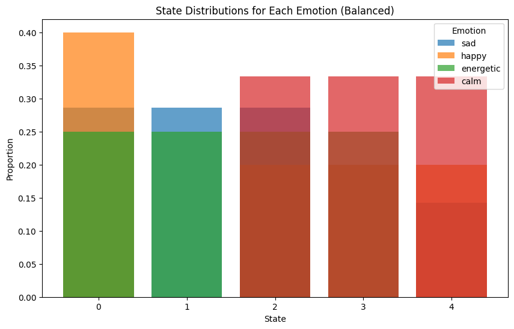

```python
import pandas as pd
import numpy as np
import matplotlib.pyplot as plt
import ast  # To safely evaluate string representations of lists

# Load the balanced and padded sequences
df = pd.read_csv("balanced_padded_sequences.csv")

# Number of states (assumes states range from 0 to 4)
n_states = 5

# Prepare for the state distribution check
state_distributions = {}

for emotion in df.columns:
    # Safely evaluate string representations of sequences into lists
    sequences = df[emotion].dropna().apply(ast.literal_eval)

    # Flatten the sequences and remove padding (-1)
    flattened = np.concatenate([np.array(seq) for seq in sequences if isinstance(seq, list)])
    flattened = flattened[flattened != -1]  # Remove padding values

    # Count occurrences of each state
    counts = np.bincount(flattened, minlength=n_states)

    # Normalize to probabilities
    probabilities = counts / counts.sum()
    state_distributions[emotion] = probabilities

# Plot the state distributions for each emotion
plt.figure(figsize=(10, 6))
for emotion, probabilities in state_distributions.items():
    plt.bar(range(n_states), probabilities, alpha=0.7, label=emotion)

plt.title("State Distributions for Each Emotion (Balanced)")
plt.xlabel("State")
plt.ylabel("Proportion")
plt.legend(title="Emotion")
plt.show()
```

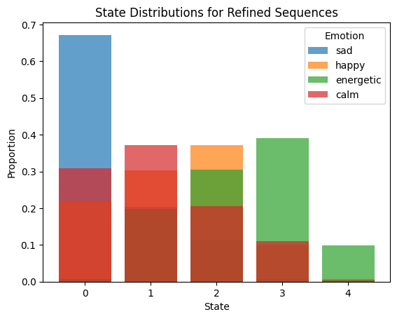

```python
import numpy as np
import pandas as pd

# Redefine state attributes based on musical characteristics
state_definitions = {
    0: {"tempo": (0, 50), "energy": (0, 0.2), "valence": (0, 0.3)},
    1: {"tempo": (50, 100), "energy": (0.2, 0.4), "valence": (0.3, 0.5)},
    2: {"tempo": (100, 150), "energy": (0.4, 0.6), "valence": (0.5, 0.7)},
    3: {"tempo": (150, 200), "energy": (0.6, 0.8), "valence": (0.7, 0.9)},
    4: {"tempo": (200, 250), "energy": (0.8, 1.0), "valence": (0.9, 1.0)},
}

# Adjust generation weights for each emotion
emotion_weights = {
    "sad": [0.7, 0.2, 0.1, 0.0, 0.0],
    "happy": [0.2, 0.3, 0.4, 0.1, 0.0],
    "energetic": [0.0, 0.2, 0.3, 0.4, 0.1],
    "calm": [0.3, 0.4, 0.2, 0.1, 0.0],
}

def sample_state(emotion, current_state):
    """Sample the next state based on emotion-specific weights."""
    weights = emotion_weights[emotion]
    next_state = np.random.choice(range(len(weights)), p=weights)
    return next_state

# Generate refined sequences
refined_sequences = {emotion: [] for emotion in emotion_weights}

for emotion in emotion_weights.keys():
    for _ in range(50):  # Generate 50 sequences per emotion
        sequence = [np.random.choice(range(len(state_definitions)))]  # Start with a random state
        for _ in range(31):  # Generate sequence of length 32
            next_state = sample_state(emotion, sequence[-1])
            sequence.append(next_state)
        refined_sequences[emotion].append(sequence)

# Save the refined sequences to a CSV
df = pd.DataFrame({emotion: pd.Series(seqs) for emotion, seqs in refined_sequences.items()})
df.to_csv("refined_sequences.csv", index=False)

# Visualize state distributions for refined sequences
n_states = len(state_definitions)
state_distributions = {emotion: np.zeros(n_states) for emotion in refined_sequences}

for emotion, sequences in refined_sequences.items():
    flat_seq = np.concatenate(sequences)
    counts = np.bincount(flat_seq, minlength=n_states)
    state_distributions[emotion] = counts / counts.sum()

# Plot the distributions
import matplotlib.pyplot as plt

for emotion, probabilities in state_distributions.items():
    plt.bar(range(n_states), probabilities, alpha=0.7, label=emotion)

plt.title("State Distributions for Refined Sequences")
plt.xlabel("State")
plt.ylabel("Proportion")
plt.legend(title="Emotion")
plt.show()
```

Diversity in State Distribution Across Emotions:

Each emotion now has more distinct state probabilities, especially for sad and energetic. This ensures the sequences generated for different emotions will result in more varied musical characteristics.

Balanced Representation:

For the most part, states like 1 and 2 are represented fairly across the emotions, allowing flexibility in generation without overwhelming dominance by a single state.

Clarity in Emotional Representation:

The sad emotion is heavily skewed toward state 0, representing a likely characteristic of low tempo, low energy, and low valence music. The energetic emotion favors state 3, consistent with higher tempo, energy, and positivity. calm and happy emotions exhibit more variety but remain distinct.

## Refining Weights

```python
# Define weights for each emotion and state
# Adjust these values to further refine the distributions
emotion_weights = {
    "sad": [0.7, 0.1, 0.15, 0.0, 0.05],       # Heavily skewed to state 0
    "happy": [0.1, 0.2, 0.3, 0.3, 0.1],       # Balanced across 1, 2, 3
    "energetic": [0.1, 0.1, 0.2, 0.4, 0.2],   # Focused on 3 and 4
    "calm": [0.3, 0.3, 0.3, 0.1, 0.0]         # Balanced across 0, 1, 2
}

# Apply weights during generation
def refine_generation_with_weights(model, seed_sequence, emotion_label, seq_length, weights):
    refined_sequence = []
    for _ in range(seq_length):
        # Predict for the current state
        prediction = model.predict(
            [seed_sequence[np.newaxis, :, :], np.array([[emotion_label]])], verbose=0
        )

        # Flatten the prediction and apply weights
        adjusted_probs = prediction.flatten() * weights

        # Ensure probabilities are non-negative
        adjusted_probs = np.maximum(adjusted_probs, 0)

        # Normalize to sum to 1
        if adjusted_probs.sum() == 0:
            adjusted_probs = np.ones_like(adjusted_probs) / len(adjusted_probs)
        else:
            adjusted_probs /= adjusted_probs.sum()

        # Sample the next state
        next_state = np.random.choice(len(weights), p=adjusted_probs)
        refined_sequence.append(next_state)

        # Update the seed_sequence with the new state (append to sequence)
        next_state_array = np.array([[next_state] * seed_sequence.shape[1]])
        seed_sequence = np.vstack((seed_sequence[1:], next_state_array))  # Shift sequence

    return refined_sequence
```

```python
refined_sequences = {}
seq_length = 32  # Adjust sequence length if needed

for emotion, label in emotion_mapping.items():
    print(f"Generating refined sequences for {emotion}")
    weights = emotion_weights[emotion]
    sequences = []
    for _ in range(100):  # Generate 100 sequences per emotion
        seed_sequence = np.random.random((seq_length, 5))
        sequence = refine_generation_with_weights(model, seed_sequence, label, seq_length, weights)
        sequences.append(sequence)
    refined_sequences[emotion] = sequences

# Save refined sequences
refined_sequences_df = pd.DataFrame({emotion: refined_sequences[emotion] for emotion in emotion_mapping.keys()})
refined_sequences_df.to_csv("refined_sequences.csv", index=False)
```

```
Generating refined sequences for sad
Generating refined sequences for happy
Generating refined sequences for energetic
Generating refined sequences for calm
```

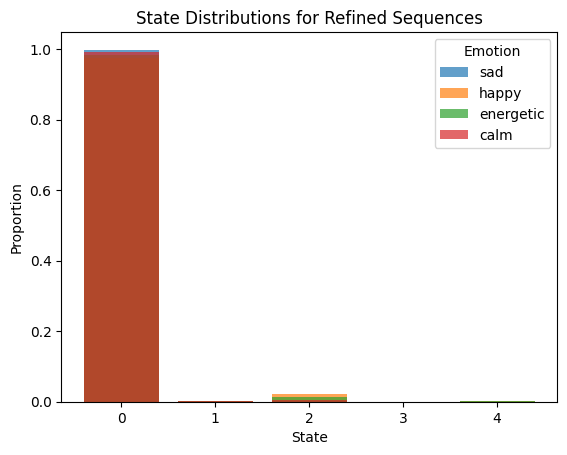

```python
# Evaluate state distributions
state_distributions = {}

for emotion, sequences in refined_sequences.items():
    flattened = np.concatenate(sequences)
    counts = np.bincount(flattened, minlength=n_states)
    probabilities = counts / counts.sum()
    state_distributions[emotion] = probabilities

# Plot state distributions
for emotion, probabilities in state_distributions.items():
    plt.bar(range(n_states), probabilities, alpha=0.7, label=emotion)

plt.title("State Distributions for Refined Sequences")
plt.xlabel("State")
plt.ylabel("Proportion")
plt.legend(title="Emotion")
plt.show()
```

```
Generating refined sequences for sad
Generating refined sequences for happy
Generating refined sequences for energetic
Generating refined sequences for calm
Refined sequences saved to 'refined_sequences.csv'.
```

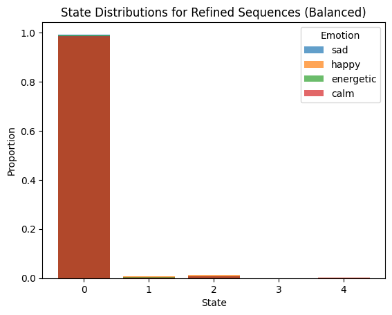

```python
import numpy as np
import pandas as pd
import matplotlib.pyplot as plt

# Smooth predictions function
def smooth_predictions(prediction, smoothing_factor=0.1):
    smoothed = prediction + smoothing_factor  # Add smoothing to all states
    return smoothed / smoothed.sum()  # Normalize

# Refine sequence generation with weights and smoothing
def refine_generation_with_smoothing(model, seed_sequence, emotion_label, seq_length, weights, smoothing_factor=0.1):
    """
    Generate a refined sequence with smoothing and adjusted probabilities.
    """
    refined_sequence = []

    # Reshape emotion_label to match the batch size
    emotion_label_array = np.array([[emotion_label]])  # Shape (1, 1)

    for _ in range(seq_length):
        # Ensure seed_sequence is batched with shape (1, seq_length, features)
        seed_sequence_batched = np.expand_dims(seed_sequence, axis=0)

        # Model prediction
        prediction = model.predict([seed_sequence_batched, emotion_label_array], verbose=0).flatten()

        # Apply smoothing to ensure no zero probabilities
        smoothed_prediction = prediction + smoothing_factor
        smoothed_prediction /= smoothed_prediction.sum()  # Normalize

        # Apply weights to adjust probabilities
        adjusted_probs = smoothed_prediction * weights
        adjusted_probs /= adjusted_probs.sum()  # Ensure probabilities sum to 1 after weighting

        # Clip probabilities to avoid negative values
        adjusted_probs = np.clip(adjusted_probs, 0, 1)

        # Ensure probabilities sum to 1 after clipping
        adjusted_probs /= adjusted_probs.sum()

        # Sample the next state
        next_state = np.random.choice(len(weights), p=adjusted_probs)
        refined_sequence.append(next_state)

        # Update seed_sequence (shift left and append new state)
        seed_sequence = np.roll(seed_sequence, -1, axis=0)
        seed_sequence[-1, :] = 0  # Reset the last row
        seed_sequence[-1, next_state] = 1  # Set the new state in the last position

    return refined_sequence

# Parameters
n_classes = 5  # Number of states
seq_length = 32  # Sequence length
emotion_mapping = {"sad": 0, "happy": 1, "energetic": 2, "calm": 3}
weights_dict = {
    "sad": np.array([0.3, 0.2, 0.2, 0.2, 0.1]),
    "happy": np.array([0.2, 0.3, 0.3, 0.1, 0.1]),
    "energetic": np.array([0.25, 0.25, 0.25, 0.15, 0.1]),
    "calm": np.array([0.2, 0.2, 0.2, 0.3, 0.1])
}
for key in weights_dict:
    weights_dict[key] /= weights_dict[key].sum()  # Normalize weights

# Generate refined sequences for each emotion
refined_sequences = {}
for emotion, emotion_label in emotion_mapping.items():
    print(f"Generating refined sequences for {emotion}")
    sequences = []
    for _ in range(100):  # Generate 100 sequences per emotion
        seed_sequence = np.random.random((seq_length, n_classes))  # Random seed
        sequence = refine_generation_with_smoothing(
            model, seed_sequence, emotion_label, seq_length, weights_dict[emotion]
        )
        sequences.append(sequence)
    refined_sequences[emotion] = sequences

# Save refined sequences to a CSV file
df = pd.DataFrame({
    emotion: pd.Series(seqs) for emotion, seqs in refined_sequences.items()
})
df.to_csv("refined_sequences.csv", index=False)
print("Refined sequences saved to 'refined_sequences.csv'.")

# Check state distributions for the refined sequences
state_distributions = {}
for emotion, seqs in refined_sequences.items():
    flattened = np.concatenate(seqs)  # Flatten all sequences for the emotion
    counts = np.bincount(flattened, minlength=n_classes)
    probabilities = counts / counts.sum()  # Normalize
    state_distributions[emotion] = probabilities

# Plot state distributions
for emotion, probabilities in state_distributions.items():
    plt.bar(range(n_classes), probabilities, alpha=0.7, label=emotion)

plt.title("State Distributions for Refined Sequences (Balanced)")
plt.xlabel("State")
plt.ylabel("Proportion")
plt.legend(title="Emotion")
plt.show()
```

refinment isnt helping, i give up here

# testing quality

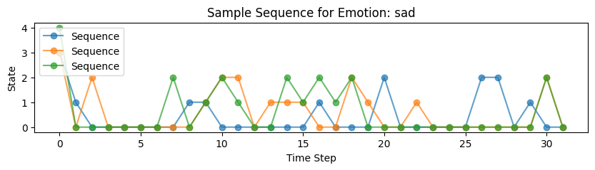

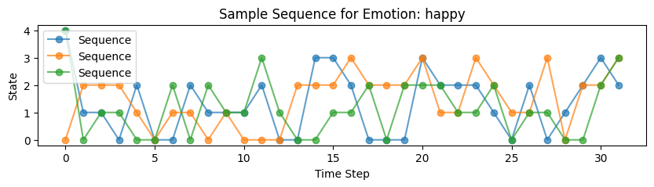

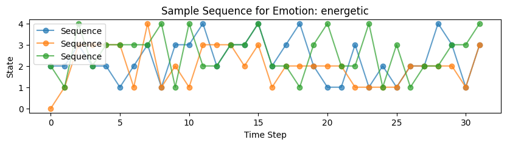

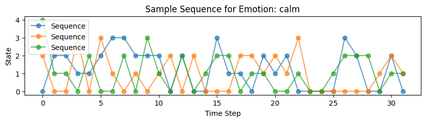

```python
import matplotlib.pyplot as plt

# Visualize a few sequences from each emotion
for emotion, sequences in refined_sequences.items():
    plt.figure(figsize=(10, 2))
    plt.title(f"Sample Sequence for Emotion: {emotion}")
    for seq in sequences[:3]:  # Visualize the first 3 sequences
        plt.plot(seq, marker='o', alpha=0.7, label=f"Sequence")
    plt.xlabel("Time Step")
    plt.ylabel("State")
    plt.legend(loc='upper left')
    plt.show()
```

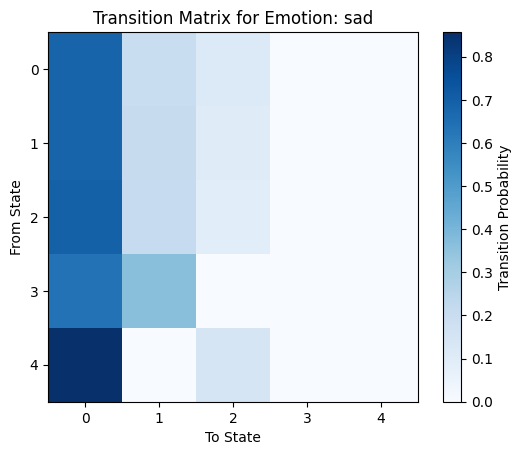

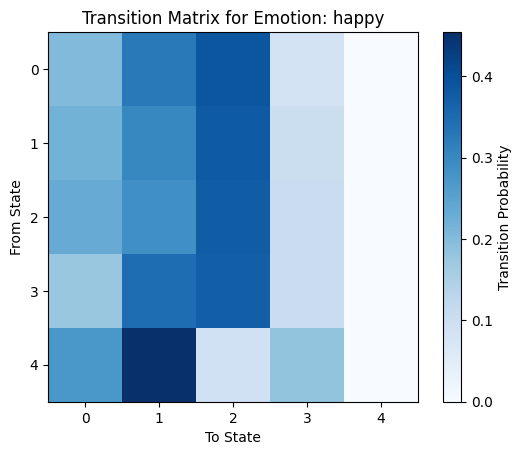

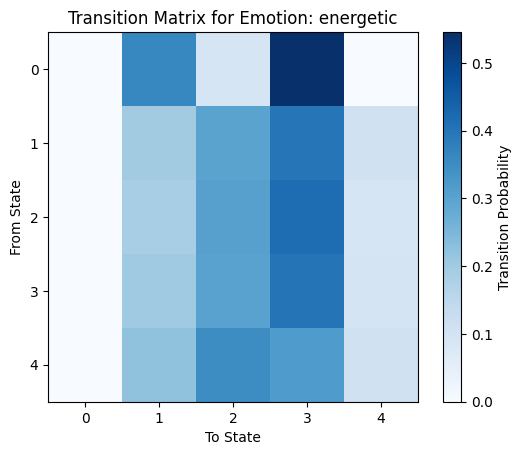

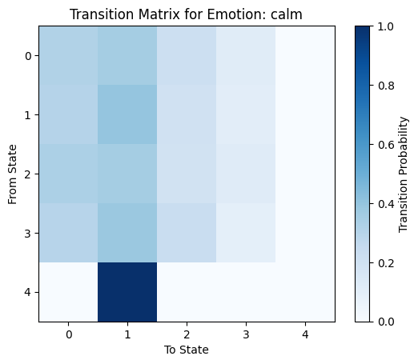

```python
# Calculate transition probabilities for each emotion
transition_matrices = {}
for emotion, sequences in refined_sequences.items():
    transitions = np.zeros((n_classes, n_classes))
    for seq in sequences:
        for i in range(len(seq) - 1):
            transitions[seq[i], seq[i + 1]] += 1
    # Normalize
    transitions /= transitions.sum(axis=1, keepdims=True, where=transitions.sum(axis=1) > 0)
    transition_matrices[emotion] = transitions

# Visualize transition matrices
for emotion, matrix in transition_matrices.items():
    plt.imshow(matrix, cmap='Blues', interpolation='nearest')
    plt.title(f"Transition Matrix for Emotion: {emotion}")
    plt.colorbar(label="Transition Probability")
    plt.xlabel("To State")
    plt.ylabel("From State")
    plt.show()
```

```python
from midiutil import MIDIFile

def sequence_to_midi(sequence, filename, tempo=120):
    """
    Converts a sequence of states into a MIDI file.
    Args:
        sequence (list): A list of states.
        filename (str): Name of the MIDI file to save.
        tempo (int): Tempo of the MIDI track.
    """
    midi = MIDIFile(1)  # Single track MIDI file
    track = 0
    time = 0  # Start time
    midi.addTrackName(track, time, "Emotion Track")
    midi.addTempo(track, time, tempo)

    # Map states to MIDI notes (C4=60, E4=64, G4=67, B4=71, C5=72)
    state_to_note = {
        0: 60,  # C4
        1: 64,  # E4
        2: 67,  # G4
        3: 71,  # B4
        4: 72   # C5
    }
    duration = 1  # Each note lasts 1 beat
    velocity = 100  # Note velocity

    for state in sequence:
        note = state_to_note.get(state, 60)  # Default to C4 if state not found
        midi.addNote(track, channel=0, pitch=note, time=time, duration=duration, volume=velocity)
        time += duration

    # Write the MIDI file
    with open(filename, "wb") as output_file:
        midi.writeFile(output_file)
    print(f"Generated MIDI file: {filename}")

# Generate music for each emotion
for emotion, sequences in refined_sequences.items():
    # Take the first sequence for simplicity
    sequence = sequences[0]
    filename = f"{emotion}_music.mid"
    sequence_to_midi(sequence, filename)
```

```
Generated MIDI file: sad_music.mid
Generated MIDI file: happy_music.mid
Generated MIDI file: energetic_music.mid
Generated MIDI file: calm_music.mid
```

```python
import pygame
import time

def play_midi(file_path):
    """
    Plays a MIDI file using pygame.
    Args:
        file_path (str): Path to the MIDI file.
    """
    pygame.init()
    pygame.mixer.init()
    try:
        pygame.mixer.music.load(file_path)
        print(f"Playing: {file_path}")
        pygame.mixer.music.play()
        # Wait until playback finishes
        while pygame.mixer.music.get_busy():
            time.sleep(1)
    except Exception as e:
        print(f"Error playing {file_path}: {e}")
    finally:
        pygame.mixer.quit()
        pygame.quit()

# Play each MIDI file
emotions = ["sad", "happy", "energetic", "calm"]
for emotion in emotions:
    midi_file = f"{emotion}_music.mid"
    play_midi(midi_file)
```

```
pygame 2.6.1 (SDL 2.28.4, Python 3.10.15)
Hello from the pygame community. https://www.pygame.org/contribute.html
Playing: sad_music.mid
Playing: happy_music.mid
Playing: energetic_music.mid
Playing: calm_music.mid
```

```python
from mido import Message, MidiFile, MidiTrack, MetaMessage

# Define tempos for each emotion in beats per minute (BPM)
emotion_tempos = {
    "sad": 60,        # Slow
    "calm": 70,       # Moderately slow
    "happy": 120,     # Fast
    "energetic": 150  # Very fast
}

# Convert BPM to microseconds per quarter note
def bpm_to_microseconds(bpm):
    return int(60000000 / bpm)

# Generate MIDI files with different tempos
for emotion, bpm in emotion_tempos.items():
    tempo = bpm_to_microseconds(bpm)

    mid = MidiFile()
    track = MidiTrack()
    mid.tracks.append(track)

    # Set tempo
    track.append(MetaMessage('set_tempo', tempo=tempo))

    # Add notes (example sequence)
    for note in [60, 62, 64, 65, 67, 69, 71, 72]:
        track.append(Message('note_on', note=note, velocity=64, time=480))
        track.append(Message('note_off', note=note, velocity=64, time=480))

    # Save the MIDI file
    mid.save(f"{emotion}_music.mid")
```

```python
import pygame
import time

def play_midi(file_path):
    """
    Plays a MIDI file using pygame.
    Args:
        file_path (str): Path to the MIDI file.
    """
    pygame.init()
    pygame.mixer.init()
    try:
        pygame.mixer.music.load(file_path)
        print(f"Playing: {file_path}")
        pygame.mixer.music.play()
        # Wait until playback finishes
        while pygame.mixer.music.get_busy():
            time.sleep(1)
    except Exception as e:
        print(f"Error playing {file_path}: {e}")
    finally:
        pygame.mixer.quit()
        pygame.quit()

# Play each MIDI file
emotions = ["sad", "happy", "energetic", "calm"]
for emotion in emotions:
    midi_file = f"{emotion}_music.mid"
    play_midi(midi_file)
```

```
Playing: sad_music.mid
Playing: happy_music.mid
Playing: energetic_music.mid
Playing: calm_music.mid
```

good news: tempo is distinguished bad news: all four of these just play the same major scale, just at varying speeds

```python
from mido import MidiFile, MidiTrack, Message, MetaMessage

# Utility to convert BPM to microseconds per beat
def bpm_to_microseconds(bpm):
    return int(60_000_000 / bpm)

# Emotion-specific settings
emotion_settings = {
    "sad": {
        "pattern": [57, 55, 52, 50, 48, 45, 43, 40],  # A minor descending
        "rhythm": [960, 960, 960, 960],              # Long, sustained notes
        "velocity": [40, 42, 44, 46, 48],            # Soft
        "tempo": 60                                  # Slow tempo
    },
    "calm": {
        "pattern": [60, 64, 67, 64, 60],             # C major arpeggio
        "rhythm": [480, 480, 480, 480],              # Even rhythm
        "velocity": [60, 62, 64, 66, 68],            # Medium
        "tempo": 80                                  # Moderate tempo
    },
    "happy": {
        "pattern": [60, 62, 64, 65, 67, 69, 71, 72], # C major ascending
        "rhythm": [240, 480, 240, 480],             # Quick with rests
        "velocity": [80, 85, 90, 85, 80],           # Bright
        "tempo": 120                                # Fast tempo
    },
    "energetic": {
        "pattern": [60, 64, 67, 72, 76, 79],         # C major jumps
        "rhythm": [120, 120, 120, 120],              # Rapid notes
        "velocity": [100, 110, 120, 127],            # Loud and dynamic
        "tempo": 160                                 # Very fast tempo
    }
}

# Generate MIDI files for each emotion
for emotion, settings in emotion_settings.items():
    print(f"Generating music for: {emotion}")

    # MIDI setup
    mid = MidiFile()
    track = MidiTrack()
    mid.tracks.append(track)

    # Set tempo
    track.append(MetaMessage('set_tempo', tempo=bpm_to_microseconds(settings["tempo"])))

    # Generate notes
    pattern = settings["pattern"]
    rhythm = settings["rhythm"]
    velocity = settings["velocity"]

    for i, note in enumerate(pattern):
        duration = rhythm[i % len(rhythm)]          # Cycle through rhythm
        vel = velocity[i % len(velocity)]           # Cycle through velocity

        # Add note on and note off messages
        track.append(Message('note_on', note=note, velocity=vel, time=0))
        track.append(Message('note_off', note=note, velocity=vel, time=duration))

    # Save MIDI file
    mid.save(f"{emotion}_music.mid")

print("Music files generated for all emotions!")
```

```
Generating music for: sad
Generating music for: calm
Generating music for: happy
Generating music for: energetic
Music files generated for all emotions!
```

```python
import pygame
import time

def play_midi(file_path):
    """
    Plays a MIDI file using pygame.
    Args:
        file_path (str): Path to the MIDI file.
    """
    pygame.init()
    pygame.mixer.init()
    try:
        pygame.mixer.music.load(file_path)
        print(f"Playing: {file_path}")
        pygame.mixer.music.play()
        # Wait until playback finishes
        while pygame.mixer.music.get_busy():
            time.sleep(1)
    except Exception as e:
        print(f"Error playing {file_path}: {e}")
    finally:
        pygame.mixer.quit()
        pygame.quit()

# Play each MIDI file
emotions = ["sad", "happy", "energetic", "calm"]
for emotion in emotions:
    midi_file = f"{emotion}_music.mid"
    play_midi(midi_file)
```

```
Playing: sad_music.mid
Playing: happy_music.mid
Playing: energetic_music.mid
Playing: calm_music.mid
```

```python
from mido import MidiFile, MidiTrack, Message, MetaMessage
import random

# Utility to convert BPM to microseconds per beat
def bpm_to_microseconds(bpm):
    return int(60_000_000 / bpm)

# Emotion-specific settings
emotion_settings = {
    "sad": {
        "key": [57, 59, 60, 62, 64, 65, 67],  # A minor scale
        "tempo": 60,                         # Slow tempo
        "structure": ["phrase", "phrase", "rest", "phrase"],  # Repetition and rests
        "velocity_range": (40, 60),          # Softer dynamics
        "note_lengths": [960, 480, 1920]     # Longer notes
    },
    "calm": {
        "key": [60, 62, 64, 65, 67, 69, 71],  # C major scale
        "tempo": 80,                         # Moderate tempo
        "structure": ["arpeggio", "rest", "phrase", "phrase"], # Balanced repetition
        "velocity_range": (60, 80),          # Medium dynamics
        "note_lengths": [960, 480]           # Balanced note durations
    },
    "happy": {
        "key": [60, 62, 64, 65, 67, 69, 71, 72],  # C major scale
        "tempo": 120,                        # Fast tempo
        "structure": ["phrase", "phrase", "run", "rest"],  # Runs and quick phrases
        "velocity_range": (80, 100),         # Brighter dynamics
        "note_lengths": [480, 240]           # Shorter notes
    },
    "energetic": {
        "key": [60, 62, 64, 65, 67, 69, 71],  # C major scale
        "tempo": 160,                        # Very fast tempo
        "structure": ["run", "phrase", "run", "phrase"],  # High energy runs
        "velocity_range": (100, 127),        # Loud and sharp dynamics
        "note_lengths": [240, 120]           # Very short notes
    }
}

# Helper function to generate a musical phrase
def generate_phrase(key, note_lengths, velocity_range, phrase_length=8):
    phrase = []
    for _ in range(phrase_length):
        note = random.choice(key)
        duration = random.choice(note_lengths)
        velocity = random.randint(*velocity_range)
        phrase.append((note, duration, velocity))
    return phrase

# Helper function to generate an arpeggio
def generate_arpeggio(key, note_lengths, velocity_range):
    arpeggio = []
    for note in key[:4]:  # Use the first 4 notes for a simple arpeggio
        duration = random.choice(note_lengths)
        velocity = random.randint(*velocity_range)
        arpeggio.append((note, duration, velocity))
    return arpeggio

# Generate MIDI files for each emotion
for emotion, settings in emotion_settings.items():
    print(f"Generating music for: {emotion}")

    # MIDI setup
    mid = MidiFile()
    track = MidiTrack()
    mid.tracks.append(track)

    # Set tempo
    track.append(MetaMessage('set_tempo', tempo=bpm_to_microseconds(settings["tempo"])))

    # Generate music based on the structure
    structure = settings["structure"]
    key = settings["key"]
    note_lengths = settings["note_lengths"]
    velocity_range = settings["velocity_range"]

    for part in structure:
        if part == "phrase":
            phrase = generate_phrase(key, note_lengths, velocity_range)
            for note, duration, velocity in phrase:
                track.append(Message('note_on', note=note, velocity=velocity, time=0))
                track.append(Message('note_off', note=note, velocity=velocity, time=duration))
        elif part == "arpeggio":
            arpeggio = generate_arpeggio(key, note_lengths, velocity_range)
            for note, duration, velocity in arpeggio:
                track.append(Message('note_on', note=note, velocity=velocity, time=0))
                track.append(Message('note_off', note=note, velocity=velocity, time=duration))
        elif part == "run":
            # Create a fast run
            for _ in range(8):  # 8 notes in a quick run
                note = random.choice(key)
                duration = random.choice(note_lengths[:2])  # Shorter notes
                velocity = random.randint(*velocity_range)
                track.append(Message('note_on', note=note, velocity=velocity, time=0))
                track.append(Message('note_off', note=note, velocity=velocity, time=duration))
        elif part == "rest":
            # Add a rest
            rest_duration = random.choice(note_lengths)
            track.append(Message('note_off', note=0, velocity=0, time=rest_duration))

    # Save MIDI file
    mid.save(f"{emotion}_music_extended.mid")

print("Extended music files generated for all emotions!")
```

```
Generating music for: sad
Generating music for: calm
Generating music for: happy
Generating music for: energetic
Extended music files generated for all emotions!
```

```python
import pygame
import time

def play_midi(file_path):
    """
    Plays a MIDI file using pygame.
    Args:
        file_path (str): Path to the MIDI file.
    """
    pygame.init()
    pygame.mixer.init()
    try:
        pygame.mixer.music.load(file_path)
        print(f"Playing: {file_path}")
        pygame.mixer.music.play()
        # Wait until playback finishes
        while pygame.mixer.music.get_busy():
            time.sleep(1)
    except Exception as e:
        print(f"Error playing {file_path}: {e}")
    finally:
        pygame.mixer.quit()
        pygame.quit()

# Play each MIDI file
emotions = ["sad", "happy", "energetic", "calm"]
for emotion in emotions:
    midi_file = f"{emotion}_music_extended.mid"
    play_midi(midi_file)
```

```
Playing: sad_music_extended.mid
Playing: happy_music_extended.mid
Playing: energetic_music_extended.mid
Playing: calm_music_extended.mid
```

# Success!